# 07_18_2020

## The Daily Graph

### Introduction and summary.

#### The spikes continue, particularly in Leon and Fulton counties.

#### Some annecdotal data on testing in Leon County. FSU reports that it has tested 3,000 people, 115 (3.8%) were positive.

```
          07/18/2020
```

### Summary for selected counties

| Statistic | Campbell, KY | Fulton, GA | Hamilton, OH | Leon, FL |
| --- | --- | --- | --- | --- |
| Population | 93,584 | 1,063,937 | 817,473 | 293,582 |
| Cases | 365 | 12,584 | 7,586 | 2,817 |
| Deaths | 13 | 335 | 212 | 10 |
| Cases per 100,000 | 390 | 1,182 | 927 | 959 |
| Deaths per 100,000 | 13 | 31 | 25 | 3 |
| Date of first case | 3/24/20 | 3/3/20 | 3/19/20 | 3/19/20 |
| Number of Days | 116 | 137 | 121 | 121 |
| Maximum Number of Cases | 23 | 520 | 381 | 228 |

## The last 7 days

The following table displays the number of new cases for the lastest 7 days of available data in each of the counties. Zero, when it occurs, probably means a missing day's data since I calculate new cases based on the diffence in cumulative number between successive days.

| Date | Campbell | Fulton | Hamilton | Leon |
| --- | --- | --- | --- | --- |
| 7/11/20 | 9 | 333 | 218 | 85 |
| 7/12/20 | 7 | 241 | 169 | 102 |
| 7/13/20 | 3 | 485 | 96 | 100 |
| 7/14/20 | 9 | 274 | 133 | 72 |
| 7/15/20 | 1 | 392 | 100 | 86 |
| 7/16/20 | 8 | 438 | 136 | 103 |
| 7/17/20 | 14 | 400 | 171 | 108 |

## Examine new cases, moving averages

The moving averages are normalized as the number of cases per 100,000 population. As noted before, the averages are 'trailing' in that the point on the graph represents the average number of new confirmed cases for that day and the $k-1$ previous days ($k = 5,7,10$).

### A comparison of moving averages amongst the counties.

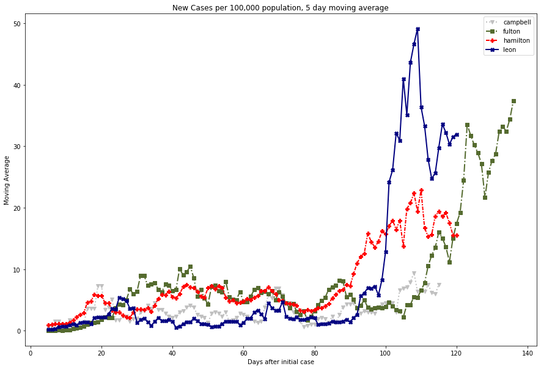

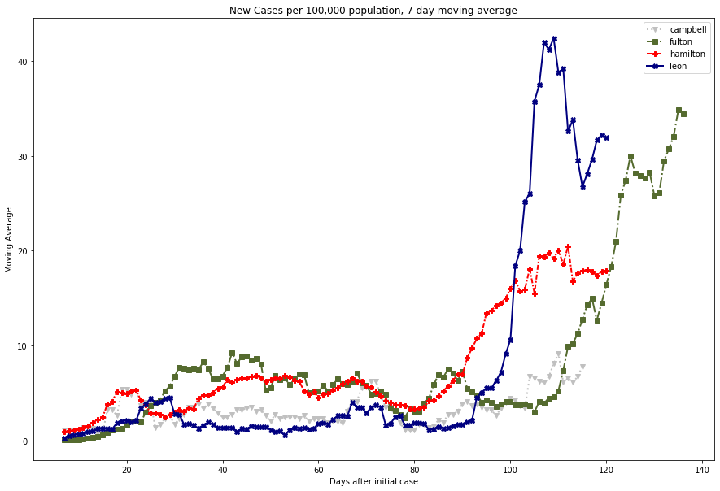

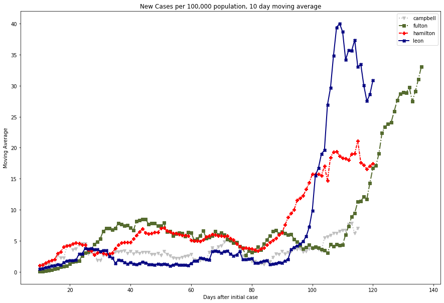

### A comparison of the different moving averages within counties.

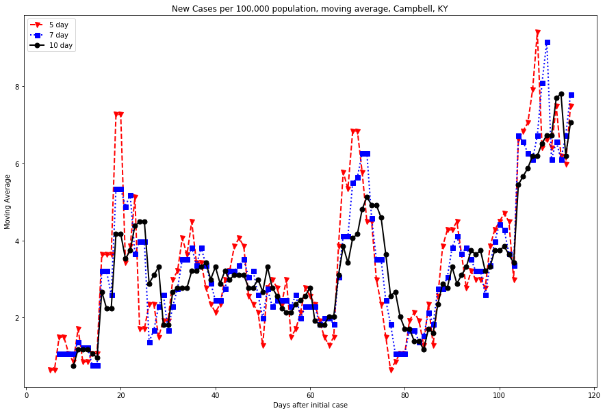

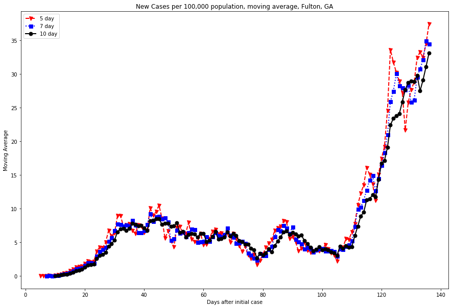

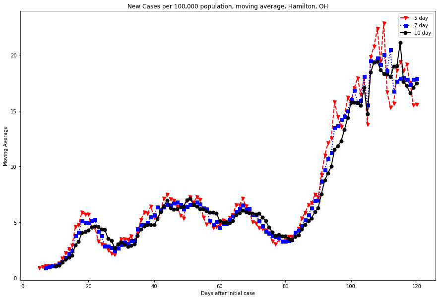

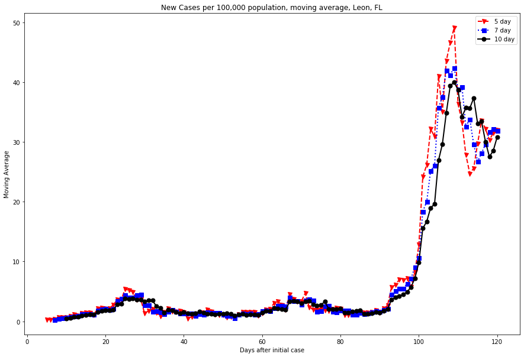

## Cumulative Number of cases by county.

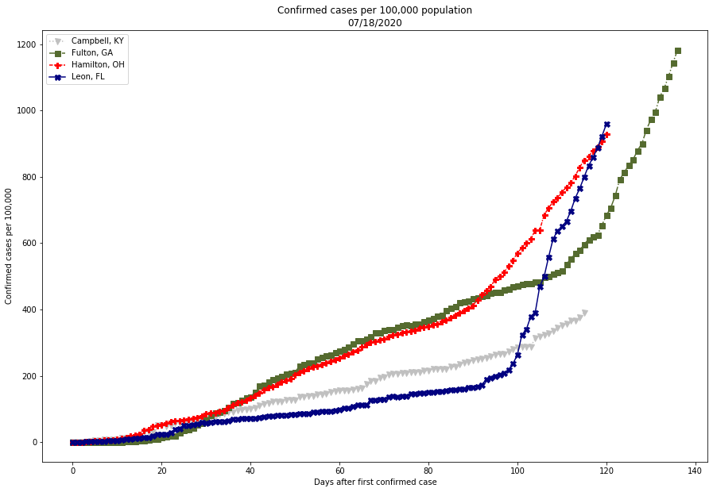

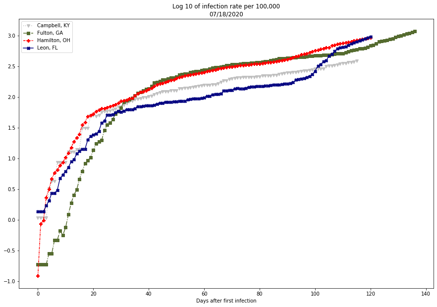